# Midterm_yutian

Yutian Luo

```r
df_test = read.csv(file = 'aug_test.csv', na.strings = "")

df_train = read.csv(file = 'aug_train.csv', na.strings = "")

df_sample = read.csv(file = 'sample_submission.csv', na.strings = "")
```

# data preprocessing

## convert to factor, change variable name

```r
df_train <-
  df_train %>% rename(relevant_experience = relevent_experience) %>%
  mutate(
    relevant_experience = str_replace(
      relevant_experience,
      pattern = "relevent",
      replacement = "relevant"
    )
  ) %>%
  mutate_if(is.character, as.factor) %>%
  mutate(target = as.factor(target)) %>%
  mutate(city_development_index = as.factor(city_development_index))

df_test <-
  df_test %>%
  rename(relevant_experience = relevent_experience) %>%
  mutate(
    relevant_experience = str_replace(
      relevant_experience,
      pattern = "relevent",
      replacement = "relevant"
    )
  )%>%
  mutate_if(is.character, as.factor) %>%
  mutate(city_development_index = as.factor(city_development_index))

knitr::kable(summary(df_train))
```

|  | enrollee_id | city | city_development_index | gender | relevant_experience | enrolled_university | education_level | major_discipline | experience | company_size | company_type | last_new_job | training_hours | target |
| --- | --- | --- | --- | --- | --- | --- | --- | --- | --- | --- | --- | --- | --- | --- |
|  | Min. : 1 | city_103:4355 | 0.92 :5200 | Female: 1238 | Has relevant experience:13792 | Full time course: 3757 | Graduate :11598 | Arts : 253 | >20 : 3286 | 50-99 :3083 | Early Stage Startup: 603 | >4 :3290 | Min. : 1.00 | 0:14381 |
|  | 1st Qu.: 8554 | city_21 :2702 | 0.624 :2702 | Male :13221 | No relevant experience : 5366 | no_enrollment :13817 | High School : 2017 | Business Degree: 327 | 5 : 1430 | 100-500 :2571 | Funded Startup :1001 | 1 :8040 | 1st Qu.: 23.00 | 1: 4777 |
|  | Median :16983 | city_16 :1533 | 0.91 :1533 | Other : 191 | NA | Part time course: 1198 | Masters : 4361 | Humanities : 669 | 4 : 1403 | 10000+ :2019 | NGO : 521 | 2 :2900 | Median : 47.00 | NA |
|  | Mean :16875 | city_114:1336 | 0.926 :1336 | NA’s : 4508 | NA | NA’s : 386 | Phd : 414 | No Major : 223 | 3 : 1354 | 10/49 :1471 | Other : 121 | 3 :1024 | Mean : 65.37 | NA |
|  | 3rd Qu.:25170 | city_160: 845 | 0.698 : 683 | NA | NA | NA | Primary School: 308 | Other : 381 | 6 : 1216 | 1000-4999:1328 | Public Sector : 955 | 4 :1029 | 3rd Qu.: 88.00 | NA |
|  | Max. :33380 | city_136: 586 | 0.897 : 586 | NA | NA | NA | NA’s : 460 | STEM :14492 | (Other):10404 | (Other) :2748 | Pvt Ltd :9817 | never:2452 | Max. :336.00 | NA |
|  | NA | (Other) :7801 | (Other):7118 | NA | NA | NA | NA | NA’s : 2813 | NA’s : 65 | NA’s :5938 | NA’s :6140 | NA’s : 423 | NA | NA |

# Exploratory Analysis and visualization

### visualize experience

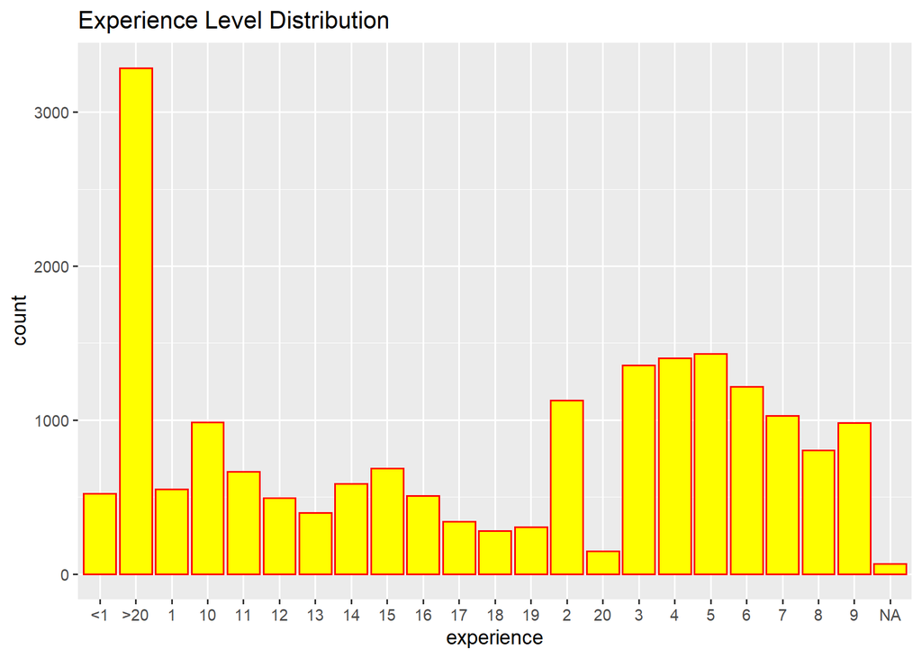

```r
df_train %>%
  dplyr::select(experience) %>%
  ggplot(aes(x = experience))+
  geom_histogram(col = 'red',
                 fill = 'yellow',
                 stat = 'count')+
  scale_fill_gradient2("Count", low="green", high="red")+
  labs(title = "Experience Level Distribution")
```

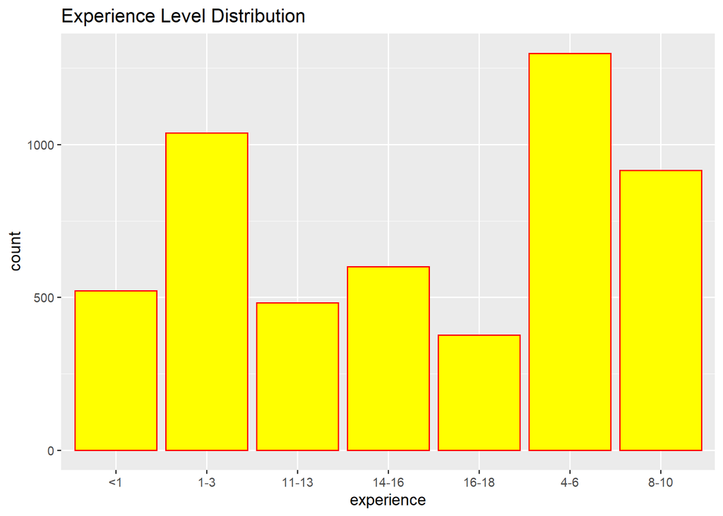

```r
ggplot2::ggsave('./result_pics/fig_exper.jpg', device = "jpg")



df_train =
  df_train %>%
  mutate(
    experience = ifelse(experience == '<1', '<1',
                      ifelse(experience == c('1','2','3'), '1-3',
                      ifelse(experience == c('4','5','6'), '4-6',
                      ifelse(experience == c('8','9','10'), '8-10',
                      ifelse(experience == c('11','12','13'), '11-13',
                      ifelse(experience == c('14','15','16'), '14-16',
                      ifelse(experience == c('16','17','18'), '16-18','>18'
                      )))))))
  ) %>%
  mutate(
    experience = as.factor(experience)
  )


df_train %>%
  dplyr::select(experience) %>%
  filter(experience !='>18') %>%
  arrange(desc(experience)) %>%
  ggplot(aes(x = experience))+
  geom_histogram(col = 'red',
                 fill = 'yellow',
                 stat = 'count')+
  scale_fill_gradient2("Count", low="green", high="red")+
  labs(title = "Experience Level Distribution")
```

```r
ggplot2::ggsave('./result_pics/fig_exper2.jpg', device = "jpg", width = 3, height = 4)
```

### Visualize missing variables

```r
jpeg('./result_pics/fig_missing.jpg', width = 500, height = 300, quality = 100)
vis_miss(df_train, sort_miss = TRUE)
dev.off()
```

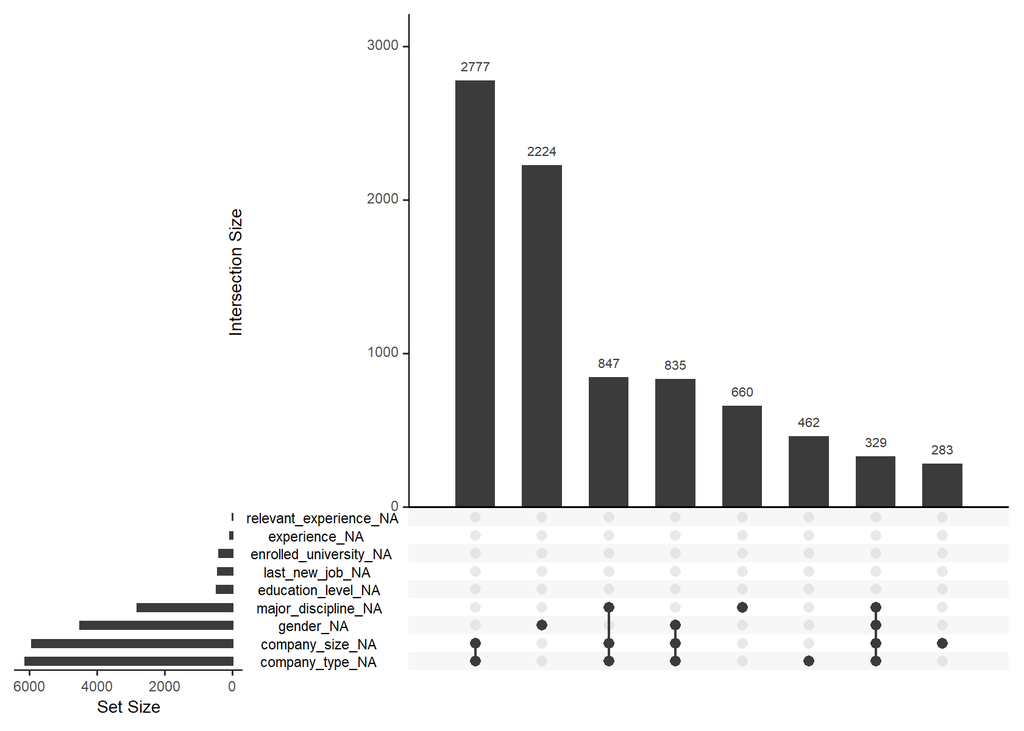

```r
gg_miss_upset(df_train,
              nsets = 10,
              nintersects = 8)
```

```r
# ggplot2::ggsave('./result_pics/fig_mssing2.jpg',
#                 device = "jpg",
#                 width = 500,
#                 height = 300,
#                 quality = 100,
#                 limitsize = FALSE)
```

This plot shows the intersection and amount of missingness. As we can see, the largest amount of missing (2777) is when company type and company size are both missing, while the second largest amount of missing (2224) is when gender alone is missing. So we can see that most of the missing has to do with company size and type not recorded and the same time.

Missing gender is a bit confusing since by intuition the interviewer must know the gender of the interviewee.

We will look more closely on these 3 variables.

### Top 3 missing variables

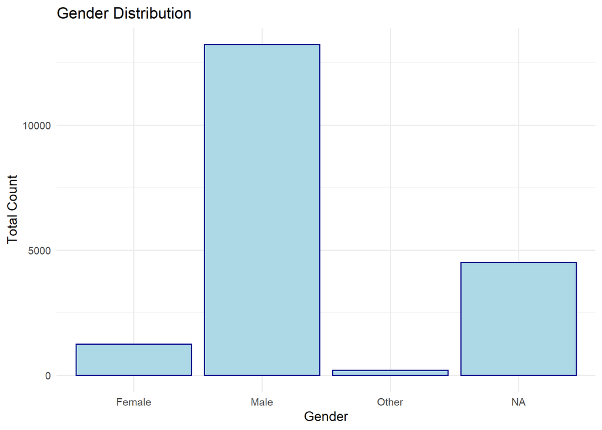

```r
# plot gender distribution
p_gender = ggplot(df_train) +
  geom_histogram(aes(gender), stat = "count", color="darkblue", fill="lightblue") +
  theme_minimal()+
  labs(
    title = "Gender Distribution",
    x = "Gender",
    y = "Total Count"
  )
p_companysize = ggplot(df_train) +
  geom_histogram(aes(company_size), stat = 'count', color = "brown", fill = "pink") +
    theme_minimal()+
  labs(
    title = "Company Size Distribution",
    x = "Company Size",
    y = "Total Count"
  )
p_company_type = ggplot(df_train) +
  geom_histogram(aes(company_type), stat = 'count', color = "white", fill = "orange")+
    theme_minimal() +
  labs(
    title = "Company Type Distribution",
    x = "Company Type",
    y = "Total Count"
  )
p_gender
```

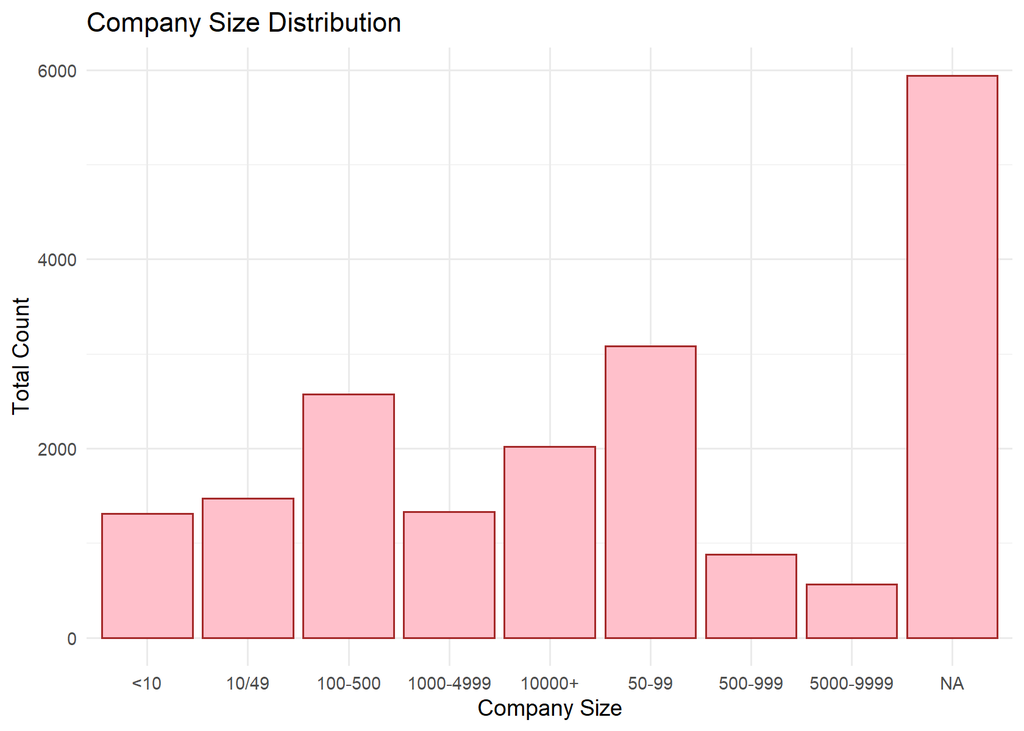

```r
ggplot2::ggsave('./result_pics/fig_gender.jpg', device = "jpg")

gridExtra::grid.arrange(p_companysize)
```

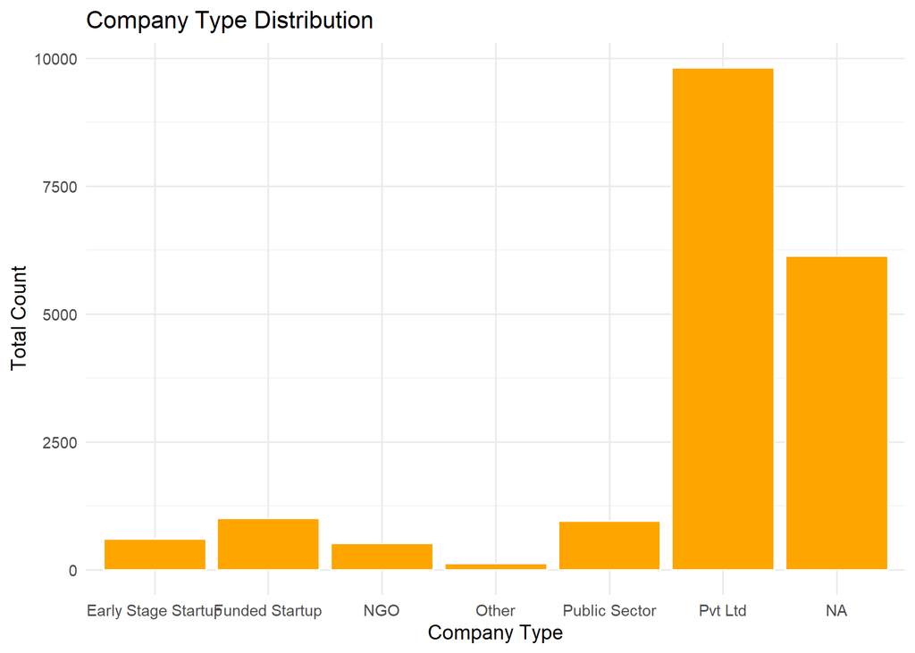

```r
ggplot2::ggsave('./result_pics/fig_company.jpg', device = "jpg")

gridExtra::grid.arrange(p_company_type)
```

```r
ggplot2::ggsave('./result_pics/fig_company_type.jpg', device = "jpg")
```

For company size and company type, each category is more evenly distributed in company size, and most interviewees are from private Ltd. this makes sense in in the job market.

After reviewing these plots, we cannot see if there the missingness is from a non- random element. It seems that for those who didn’t record company size, they also weren’t recorded for company type, this might be from recording error. Thus, the missingness from these three variables are assumed to have MAR relation. Thus, we continue to perform imputation.

# imputation

In our given data, df_train contains Y, while df_test doesn’t. If we simply impute these two df, the imputed test data will depend on the train data and cause bias. Thus, we take only the original df_train as our whole data and partition it into train set and test set to impute.

We also drop enrollee_id, city and gender as discussed.

```r
indextrain = createDataPartition(y = df_train$target,
                                 p = 0.8,
                                 list = FALSE)

aug_train_for_Im =
  df_train[indextrain, ] %>%
  dplyr::select(-enrollee_id, -city, -gender ) %>%
  mutate(
    city_development_index = as.numeric(city_development_index),
    target = as.factor(target)) %>%
  as.data.frame()


aug_test_for_Im =
  df_train[-indextrain,] %>%
  dplyr::select(-enrollee_id, -city, -gender ) %>%
  mutate(
    city_development_index = as.numeric(city_development_index)) %>%
  as.data.frame()
```

```r
# aug_train_for_Im <-
#   df_train %>%
#   select(-enrollee_id, -city, -gender ) %>%
#   mutate(
#     city_development_index = as.numeric(city_development_index),
#     target = as.factor(target)) %>%
#   as.data.frame()
#
# aug_test_for_Im <-
#   df_test %>%
#   select(-enrollee_id, -city, -gender ) %>%
#   mutate(
#     city_development_index = as.numeric(city_development_index)) %>%
#   as.data.frame()

### training data imputation

set.seed(1)

TrainDataImputed <- missForest(xmis = aug_train_for_Im, maxiter = 2, ntree = 20)
```

```
##   missForest iteration 1 in progress...done!
##   missForest iteration 2 in progress...done!
```

```r
TrainDataImputed <- TrainDataImputed$ximp

### test data imputation

set.seed(1)

TestDataImputed <- missForest(xmis = aug_test_for_Im, maxiter = 2, ntree = 20)
```

```
##   missForest iteration 1 in progress...done!
##   missForest iteration 2 in progress...done!
```

```r
TestDataImputed <- TestDataImputed$ximp
TestDataImputed <-
  TestDataImputed %>%
  mutate(city_development_index = as.numeric(city_development_index))

# train data has 15327*11
# test data has 3831*11
```

create validation set

```r
set.seed(1)

PartIndex <- createDataPartition(TrainDataImputed$target,
                                  p = .75,
                                  list = FALSE,
                                  times = 1)

New_aug_Train <- TrainDataImputed[ PartIndex,]
aug_validation  <- TrainDataImputed[-PartIndex,]
```

## data summary table

```r
# summary table
tableby.control(pval = FALSE)
```

[output not shown]

[output cut: 138 more lines]

[output not shown]

```r
table_one <- tableby(target ~ ., data = TrainDataImputed)


knitr::kable(summary(table_one, title = "HR Data"))
```

|  | 0 (N=11505) | 1 (N=3822) | Total (N=15327) | p value |
| --- | --- | --- | --- | --- |
| **city_development_index** |  |  |  | < 0.001 |
| Mean (SD) | 69.407 (25.646) | 47.004 (32.915) | 63.821 (29.288) |  |
| Range | 1.000 - 93.000 | 1.000 - 93.000 | 1.000 - 93.000 |  |
| **relevant_experience** |  |  |  | < 0.001 |
| Has relevant experience | 8668 (75.3%) | 2395 (62.7%) | 11063 (72.2%) |  |
| No relevant experience | 2837 (24.7%) | 1427 (37.3%) | 4264 (27.8%) |  |
| **enrolled_university** |  |  |  | < 0.001 |
| Full time course | 1972 (17.1%) | 1196 (31.3%) | 3168 (20.7%) |  |
| no_enrollment | 8815 (76.6%) | 2384 (62.4%) | 11199 (73.1%) |  |
| Part time course | 718 (6.2%) | 242 (6.3%) | 960 (6.3%) |  |
| **education_level** |  |  |  | < 0.001 |
| Graduate | 6739 (58.6%) | 2662 (69.6%) | 9401 (61.3%) |  |
| High School | 1388 (12.1%) | 330 (8.6%) | 1718 (11.2%) |  |
| Masters | 2797 (24.3%) | 750 (19.6%) | 3547 (23.1%) |  |
| Phd | 289 (2.5%) | 44 (1.2%) | 333 (2.2%) |  |
| Primary School | 292 (2.5%) | 36 (0.9%) | 328 (2.1%) |  |
| **major_discipline** |  |  |  | 0.015 |
| Arts | 192 (1.7%) | 43 (1.1%) | 235 (1.5%) |  |
| Business Degree | 211 (1.8%) | 67 (1.8%) | 278 (1.8%) |  |
| Humanities | 456 (4.0%) | 115 (3.0%) | 571 (3.7%) |  |
| No Major | 153 (1.3%) | 45 (1.2%) | 198 (1.3%) |  |
| Other | 230 (2.0%) | 78 (2.0%) | 308 (2.0%) |  |
| STEM | 10263 (89.2%) | 3474 (90.9%) | 13737 (89.6%) |  |
| **experience** |  |  |  | < 0.001 |
| <1 | 227 (2.0%) | 190 (5.0%) | 417 (2.7%) |  |
| >18 | 8450 (73.4%) | 2683 (70.2%) | 11133 (72.6%) |  |
| 1-3 | 547 (4.8%) | 271 (7.1%) | 818 (5.3%) |  |
| 11-13 | 297 (2.6%) | 84 (2.2%) | 381 (2.5%) |  |
| 14-16 | 395 (3.4%) | 84 (2.2%) | 479 (3.1%) |  |
| 16-18 | 251 (2.2%) | 39 (1.0%) | 290 (1.9%) |  |
| 4-6 | 754 (6.6%) | 307 (8.0%) | 1061 (6.9%) |  |
| 8-10 | 584 (5.1%) | 164 (4.3%) | 748 (4.9%) |  |
| **company_size** |  |  |  | < 0.001 |
| <10 | 1522 (13.2%) | 464 (12.1%) | 1986 (13.0%) |  |
| 10/49 | 1066 (9.3%) | 623 (16.3%) | 1689 (11.0%) |  |
| 100-500 | 1997 (17.4%) | 462 (12.1%) | 2459 (16.0%) |  |
| 1000-4999 | 1286 (11.2%) | 411 (10.8%) | 1697 (11.1%) |  |
| 10000+ | 1822 (15.8%) | 684 (17.9%) | 2506 (16.4%) |  |
| 50-99 | 2283 (19.8%) | 543 (14.2%) | 2826 (18.4%) |  |
| 500-999 | 889 (7.7%) | 299 (7.8%) | 1188 (7.8%) |  |
| 5000-9999 | 640 (5.6%) | 336 (8.8%) | 976 (6.4%) |  |
| **company_type** |  |  |  | < 0.001 |
| Early Stage Startup | 743 (6.5%) | 316 (8.3%) | 1059 (6.9%) |  |
| Funded Startup | 876 (7.6%) | 171 (4.5%) | 1047 (6.8%) |  |
| NGO | 474 (4.1%) | 139 (3.6%) | 613 (4.0%) |  |
| Other | 88 (0.8%) | 35 (0.9%) | 123 (0.8%) |  |
| Public Sector | 918 (8.0%) | 604 (15.8%) | 1522 (9.9%) |  |
| Pvt Ltd | 8406 (73.1%) | 2557 (66.9%) | 10963 (71.5%) |  |
| **last_new_job** |  |  |  | < 0.001 |
| >4 | 2171 (18.9%) | 476 (12.5%) | 2647 (17.3%) |  |
| 1 | 4801 (41.7%) | 1748 (45.7%) | 6549 (42.7%) |  |
| 2 | 1762 (15.3%) | 593 (15.5%) | 2355 (15.4%) |  |
| 3 | 652 (5.7%) | 195 (5.1%) | 847 (5.5%) |  |
| 4 | 641 (5.6%) | 178 (4.7%) | 819 (5.3%) |  |
| never | 1478 (12.8%) | 632 (16.5%) | 2110 (13.8%) |  |
| **training_hours** |  |  |  | 0.016 |
| Mean (SD) | 66.268 (61.096) | 63.543 (58.044) | 65.588 (60.359) |  |
| Range | 1.000 - 336.000 | 1.000 - 336.000 | 1.000 - 336.000 |  |

Next step, we will perform model training.

# models

## Logistics Regression

```r
contrasts(df_train$target)
```

```
##   1
## 0 0
## 1 1
```

```r
logit_fit = glm(target~.,
                data = TrainDataImputed,
                family = binomial(link = 'logit'))

summary(logit_fit)
```

```
##
## Call:
## glm(formula = target ~ ., family = binomial(link = "logit"),
##     data = TrainDataImputed)
##
## Deviance Residuals:
##     Min       1Q   Median       3Q      Max
## -2.1648  -0.6842  -0.4919  -0.2340   2.7418
##
## Coefficients:
##                                             Estimate Std. Error z value
## (Intercept)                                0.9712261  0.2457415   3.952
## city_development_index                    -0.0260330  0.0007162 -36.350
## relevant_experienceNo relevant experience  0.4188356  0.0540371   7.751
## enrolled_universityno_enrollment          -0.2691964  0.0548572  -4.907
## enrolled_universityPart time course       -0.3096470  0.0920579  -3.364
## education_levelHigh School                -0.6867338  0.0779857  -8.806
## education_levelMasters                    -0.3117074  0.0516537  -6.035
## education_levelPhd                        -0.8419292  0.1754646  -4.798
## education_levelPrimary School             -1.2691711  0.1944444  -6.527
## major_disciplineBusiness Degree            0.0219087  0.2340009   0.094
## major_disciplineHumanities                -0.0710365  0.2105652  -0.337
## major_disciplineNo Major                  -0.1059041  0.2572404  -0.412
## major_disciplineOther                     -0.2469287  0.2316508  -1.066
## major_disciplineSTEM                      -0.1700787  0.1803908  -0.943
## experience>18                             -0.4709307  0.1160190  -4.059
## experience1-3                             -0.4484162  0.1379205  -3.251
## experience11-13                           -0.4268317  0.1749338  -2.440
## experience14-16                           -0.5726122  0.1726692  -3.316
## experience16-18                           -0.8529945  0.2162907  -3.944
## experience4-6                             -0.5182479  0.1348287  -3.844
## experience8-10                            -0.5570887  0.1485510  -3.750
## company_size10/49                          0.6153860  0.0843289   7.297
## company_size100-500                       -0.1773789  0.0883850  -2.007
## company_size1000-4999                      0.2784766  0.0930850   2.992
## company_size10000+                         0.4212663  0.0850103   4.955
## company_size50-99                         -0.0882171  0.0846738  -1.042
## company_size500-999                        0.1807847  0.1000089   1.808
## company_size5000-9999                      0.6876041  0.1004121   6.848
## company_typeFunded Startup                -0.2759848  0.1208905  -2.283
```

[output cut: 45 more lines]

```
## last_new_job2                             0.002448 **
## last_new_job3                             0.095622 .
## last_new_job4                             0.114047
## last_new_jobnever                         0.845423
## training_hours                            0.031326 *
## ---
## Signif. codes:  0 '***' 0.001 '**' 0.01 '*' 0.05 '.' 0.1 ' ' 1
##
## (Dispersion parameter for binomial family taken to be 1)
##
##     Null deviance: 17216  on 15326  degrees of freedom
## Residual deviance: 14666  on 15288  degrees of freedom
## AIC: 14744
##
## Number of Fisher Scoring iterations: 4
```

### performance evaluation on test set

```r
test_pred_logit = predict(logit_fit, newdata = TestDataImputed,
                          type = 'response')

test_pred = rep("0", length(test_pred_logit))
test_pred[test_pred_logit > 0.2] = '1'

confusionMatrix(data = as.factor(test_pred),
                reference = TestDataImputed$target,
                positive = '1')
```

```
## Confusion Matrix and Statistics
##
##           Reference
## Prediction    0    1
##          0 1862  241
##          1 1014  714
##
##                Accuracy : 0.6724
##                  95% CI : (0.6573, 0.6873)
##     No Information Rate : 0.7507
##     P-Value [Acc > NIR] : 1
##
##                   Kappa : 0.311
##
##  Mcnemar's Test P-Value : <2e-16
##
##             Sensitivity : 0.7476
##             Specificity : 0.6474
##          Pos Pred Value : 0.4132
##          Neg Pred Value : 0.8854
##              Prevalence : 0.2493
##          Detection Rate : 0.1864
##    Detection Prevalence : 0.4511
##       Balanced Accuracy : 0.6975
##
##        'Positive' Class : 1
##
```

Interpretation:

```r
roc_logit_fit = roc(TestDataImputed$target, test_pred_logit)
```

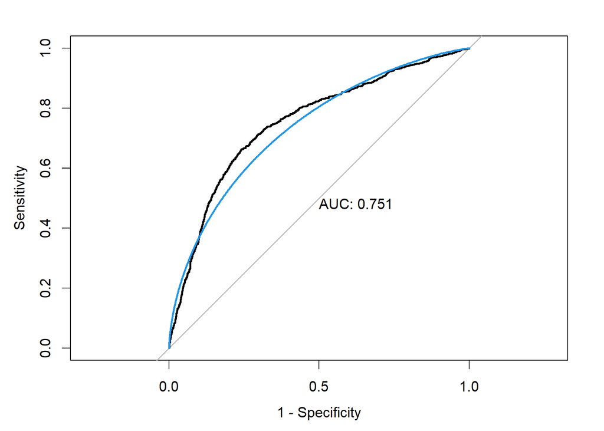

```r
plot(roc_logit_fit, legacy.axes = TRUE, print.auc = TRUE)
plot(smooth(roc_logit_fit), col = 4, add = TRUE)
```

## MARS

```r
ctrl1 <- trainControl(method="cv",number=5)

x = TrainDataImputed[-11]

y = TrainDataImputed$target

mars_grid <- expand.grid(degree=1:2,
                         nprune = 2:30)
set.seed(7)
mars.fit <- train(x,y,
                  method = "earth",
                  tuneGrid = mars_grid,
                  trControl = ctrl1)
```

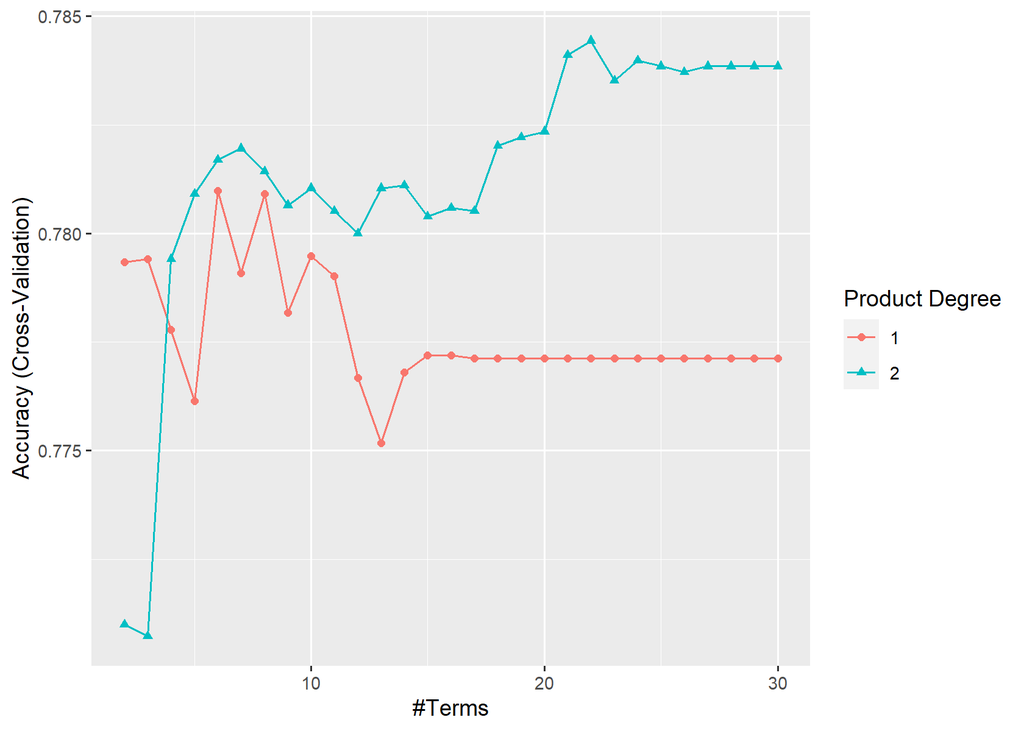

```r
ggplot(mars.fit)
```

```r
ggsave('./result_pics/mars_fit.jpg', device = 'jpg')
mars.fit$bestTune
```

|  | nprune | degree |
| --- | --- | --- |
| 50 | 22 | 2 |

Interpretation:

[output not shown]

```r
coef(mars.fit$finalModel)
```

```
##                                                               (Intercept)
##                                                                0.25521822
##                                              h(city_development_index-32)
##                                                               -0.07639398
##                  h(city_development_index-32) * company_typePublic Sector
##                                                                0.02064856
##                                                         company_size10/49
##                                                                0.45348535
##                                 relevant_experienceNo relevant experience
##                                                                0.46922267
##                                                     company_size5000-9999
##                                                                0.61141399
##                                                education_levelHigh School
##                                                               -0.34367961
## relevant_experienceNo relevant experience * education_levelPrimary School
##                                                               -1.47668232
##  h(city_development_index-86) * relevant_experienceNo relevant experience
##                                                               -0.07611753
##                                                        company_size10000+
##                                                                0.35203342
##             relevant_experienceNo relevant experience * company_size10/49
##                                                                0.60678388
##         relevant_experienceNo relevant experience * company_size1000-4999
##                                                                0.64709294
##            relevant_experienceNo relevant experience * education_levelPhd
##                                                               -1.24632856
##                     h(city_development_index-32) * education_levelMasters
##                                                               -0.00604122
##                                              h(city_development_index-15)
##                                                               -0.89323949
##                                              h(city_development_index-17)
##                                                                0.93865999
##                                              h(city_development_index-78)
##                                                                0.11271446
##                                              h(city_development_index-86)
##                                                               -0.20835518
##                                          enrolled_universityno_enrollment
##                                                               -0.24416235
##                        major_disciplineHumanities * company_size5000-9999
##                                                                1.56433902
##    relevant_experienceNo relevant experience * company_typeFunded Startup
##                                                               -1.38804157
##                            education_levelHigh School * last_new_jobnever
##                                                               -0.61119817
```

```r
jpeg('./result_pics/mars_partial.jpg')

  pdp::partial(mars.fit,pred.var=c("city_development_index"),grid.resolution=10) %>%
  autoplot()
dev.off()
```

```r
pred.earthModel <- predict(mars.fit, newdata=TestDataImputed, type="prob")[,2]


roc.earthModel <- pROC::roc(TestDataImputed$target, pred.earthModel)
```

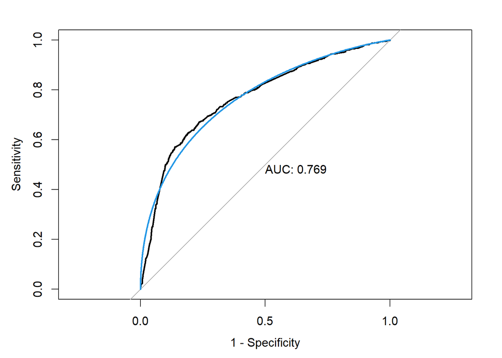

```r
auc.earthModel <- pROC::auc(roc.earthModel)

plot(roc.earthModel, legacy.axes = TRUE, print.auc = TRUE)
plot(smooth(roc.earthModel), col = 4, add = TRUE)
```

```r
jpeg("./result_pics/mars_imp_var.jpg")
vip(mars.fit$finalModel)
dev.off()
```

## LDA

```r
lda_fit = lda(target~.,
              data = TrainDataImputed
              #subset = PartIndex
              )

lda_pred = predict(lda_fit, newdata = TestDataImputed)

head(lda_pred$posterior)
```

```
##           0          1
## 1 0.8367113 0.16328874
## 2 0.9144746 0.08552536
## 3 0.4759514 0.52404858
## 4 0.5501092 0.44989081
## 5 0.9441894 0.05581062
## 6 0.6516499 0.34835007
```

```r
roc_lda = roc(TestDataImputed$target,
              lda_pred$posterior[,2],
              levels = c("0","1"))
```

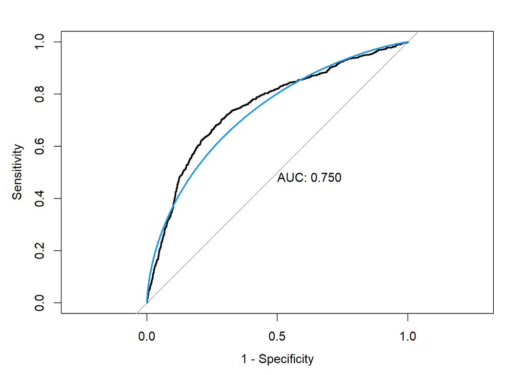

```r
plot(roc_lda, legacy.axes = TRUE, print.auc = TRUE)
plot(smooth(roc_lda), col = 4, add = TRUE)
```

## QDA

```r
qda_fit = qda(target~.,
              data = TrainDataImputed
              #subset = PartIndex
              )

qda_pred = predict(qda_fit, newdata = TestDataImputed)
head(qda_pred$posterior)
```

```
##           0            1
## 1 0.9991032 8.968494e-04
## 2 0.9348731 6.512687e-02
## 3 0.0500622 9.499378e-01
## 4 0.1700220 8.299780e-01
## 5 0.9973978 2.602194e-03
## 6 1.0000000 1.236289e-12
```

```r
roc_qda = roc(TestDataImputed$target,
              qda_pred$posterior[,2],
              levels = c("0","1"))
```

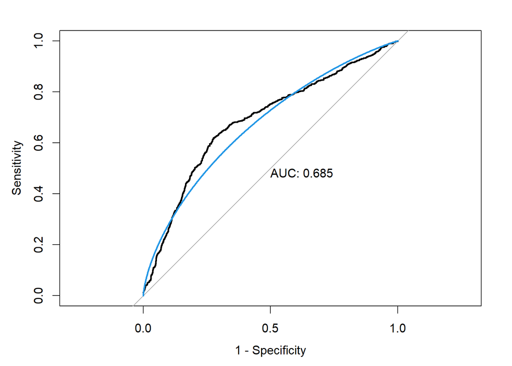

```r
plot(roc_qda, legacy.axes = TRUE, print.auc = TRUE)
plot(smooth(roc_qda), col = 4, add = TRUE)
```

## rf

```r
index = sample(1:nrow(TrainDataImputed), 300)

set.seed(1)
rf <- randomForest(target ~ . ,
                   data = TrainDataImputed[index,],
                   mtry = 3)

set.seed(1)
rf2 <- ranger(target ~ . ,
              data = TrainDataImputed[index,],
              mtry = 3,
              probability = TRUE)

# prediction
rf_pred<- predict(rf,
                  newdata = TestDataImputed,
                  type = "prob")[,1]

rf2_pred <- predict(rf2,
                    data = TestDataImputed,
                    type = "response")$predictions[,1]
```

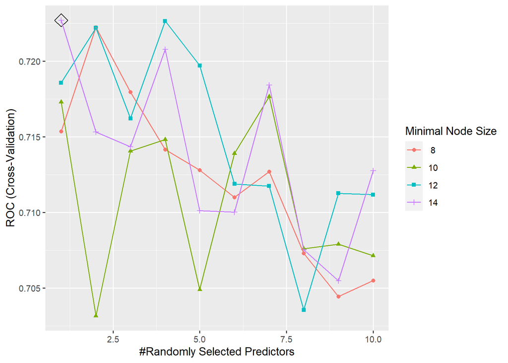

```r
index = sample(1:nrow(TrainDataImputed), 300)

ctrl <- trainControl(method = "cv",
                     classProbs = T,
                     summaryFunction = twoClassSummary)

rf.grid <- expand.grid(mtry = 1:10,
                       splitrule = "gini",
                       min.node.size = seq(from = 8, to = 15, by = 2))

TrainDataImputed_rf =
  TrainDataImputed %>%
  mutate(
    target = fct_recode(target, "yes"="1", "no" = "0")
  )

set.seed(1)
rf.fit = train(target~.,
               data = TrainDataImputed_rf[index,],
               method = "ranger",
               tuneGrid = rf.grid,
               metric = "ROC",
               trControl = ctrl)

ggplot(rf.fit, highlight = T)
```

```r
rf_pred = predict(rf.fit, newdata = TestDataImputed, type = "prob")[,1]
```

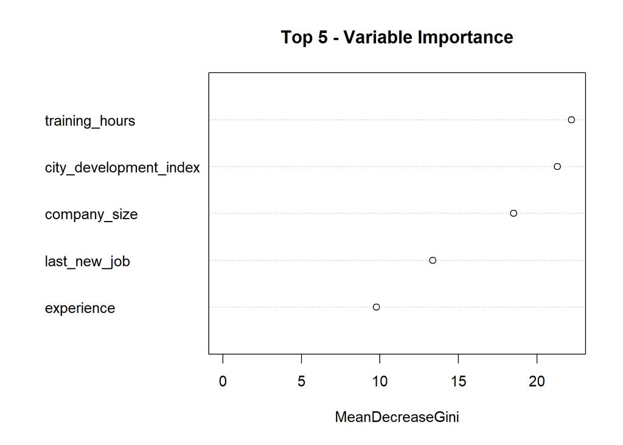

```r
varImpPlot(rf,
           sort = T,
           n.var = 5,
           main = "Top 5 - Variable Importance")
```

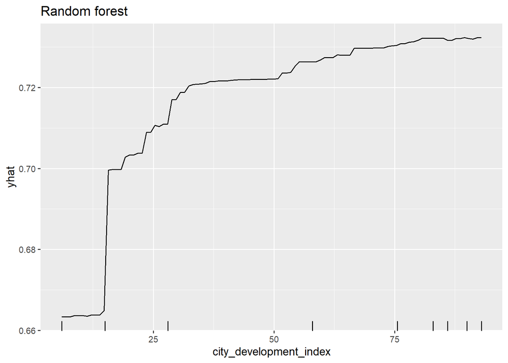

```r
pdp.rf <-
  rf.fit %>%
  partial(pred.var = "city_development_index",
          grid.resolution = 100,
          prob = TRUE) %>%
  autoplot(rug = TRUE, train = TrainDataImputed[index,]) +
  ggtitle("Random forest")

pdp.rf
```

### roc

```r
roc.rf <- roc(TestDataImputed$target, rf_pred)
roc.rf$auc
```

```
## Area under the curve: 0.7323
```

## Bagging

since this is a classification problem, we use classification tree in bagging. mtry is the number of predictors.

For randomforest bagging, mtry is p/3 = 3

```r
index = sample(1:nrow(TrainDataImputed), 300)

set.seed(1)
rf_bagging <- randomForest(target ~ . ,
                   data = TrainDataImputed[index,],
                        mtry = 3)

set.seed(1)
rf2_bagging <- ranger(target ~ . ,
              data = TrainDataImputed[index,],
              mtry = 3,
              probability = TRUE)

# prediction
rf_bagging.pred <- predict(rf_bagging,
                           newdata = TestDataImputed,
                           type = "prob")[,1]

rf2_bagging.pred <- predict(rf2_bagging,
                            data = TestDataImputed,
                            type = "response")$predictions[,1]
```

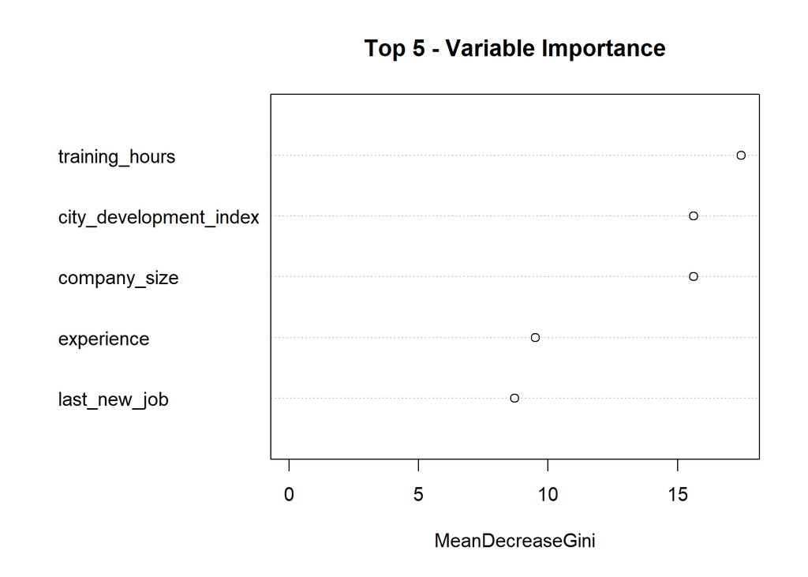

```r
varImpPlot(rf_bagging,
           sort = T,
           n.var = 5,
           main = "Top 5 - Variable Importance")
```

Interpretation:

[output not shown]

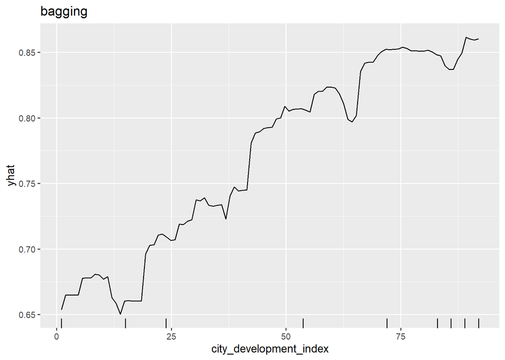

```r
pdp_rf_bagging = rf_bagging %>%
  partial(pred.var = 'city_development_index',
          grid.resolution = 100,
          prob = T) %>%
  autoplot(rug = T, train = TrainDataImputed[index,])+
  ggtitle("bagging")

pdp_rf_bagging
```

### ROC

```r
roc.bag <- roc(TestDataImputed$target, rf_bagging.pred)
roc.bag$auc
```

```
## Area under the curve: 0.6831
```

## Boosting

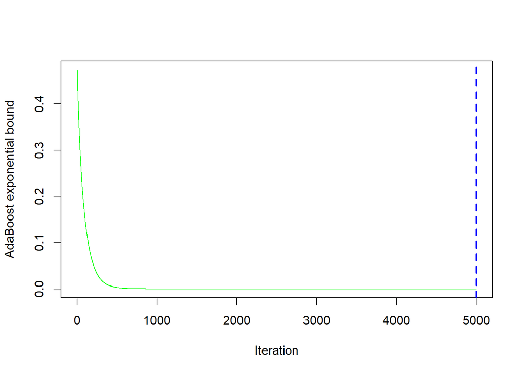

```
## [1] 5000
```

```r
set.seed(1)
bst <- gbm(target ~ . ,
           TrainDataImputed,
           distribution = "adaboost",
           n.trees = 5000,
           interaction.depth =1,
           shrinkage = 0.01,
           cv.folds = 10,
           n.cores = 2)

gbm.perf(bst, method = "cv")
```

```r
set.seed(1)
index = sample(1:nrow(TrainDataImputed), 300)
ctrl <- trainControl(method = "cv", number = 10, classProbs = T)



gbm.grid <- expand.grid(n.trees = c(3000,4000,5000),
                        interaction.depth = 1:4,
                        shrinkage = c(0.001,0.003,0.005),
                        n.minobsinnode = c(1,10))
set.seed(1)
gbm.fit <- train(target ~ . ,
                 TrainDataImputed_rf[index,],
                 method = "gbm",
                 tuneGrid = gbm.grid,
                 trControl = ctrl,
                 distribution = "adaboost",
                 metric = "ROC",
                 preProc = "zv",
                 verbose = FALSE)
```

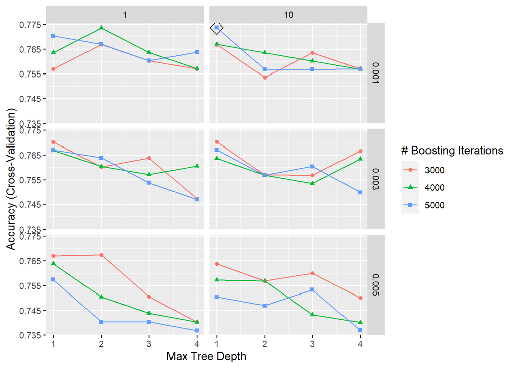

```r
ggplot(gbm.fit, highlight = TRUE)
```

```r
gbm_pred = predict(bst, data = TestDataImputed)
```

```
## Using 5000 trees...
```

### ROC

```r
roc.gbm <- roc(TrainDataImputed$target, gbm_pred)
roc.gbm$auc
```

```
## Area under the curve: 0.6595
```

## Radial Kernel

```r
ctrl_radial <- trainControl(method = "cv", number = 10)

set.seed(1)
index = sample(1:nrow(TrainDataImputed), 300)


set.seed(1)
svm_radial <- svm(target ~ .,
                  data = TrainDataImputed[index,],
                  method = 'radial',
                  cost = 0.01)
summary(svm_radial)
```

```
##
## Call:
## svm(formula = target ~ ., data = TrainDataImputed[index, ], method = "radial",
##     cost = 0.01)
##
##
## Parameters:
##    SVM-Type:  C-classification
##  SVM-Kernel:  radial
##        cost:  0.01
##
## Number of Support Vectors:  172
##
##  ( 89 83 )
##
##
## Number of Classes:  2
##
## Levels:
##  0 1
```

```r
postResample(predict(svm_radial, TrainDataImputed), TrainDataImputed$target)
```

```
##  Accuracy     Kappa
## 0.7506361 0.0000000
```

```r
postResample(predict(svm_radial, TestDataImputed), TestDataImputed$target)
```

```
##  Accuracy     Kappa
## 0.7507178 0.0000000
```

Interpretation:

```
* the model accuracy for training data is 75%
* the model accuracy for testing data is 75%
```

```r
set.seed(1)
svm_radial_tune <- train(target ~ .,
                         data = TrainDataImputed[index,],
                         method = 'svmRadial',
                         trControl = ctrl_radial,
                         preProcess = c("zv"),
                         tuneGrid = expand.grid(C = seq(0.01, 10, length.out = 20),
                                                sigma = 0.05691))
svm_radial_tune
```

```
## Support Vector Machines with Radial Basis Function Kernel
##
## 300 samples
##  10 predictor
##   2 classes: '0', '1'
##
## Pre-processing:  (None)
## Resampling: Cross-Validated (10 fold)
## Summary of sample sizes: 270, 270, 270, 270, 269, 271, ...
## Resampling results across tuning parameters:
##
##   C           Accuracy   Kappa
##    0.0100000  0.7233815  0.00000000
##    0.5357895  0.7267149  0.03694086
##    1.0615789  0.7100482  0.08967927
##    1.5873684  0.7032666  0.10851583
##    2.1131579  0.7065999  0.14363029
##    2.6389474  0.6934816  0.12089403
##    3.1647368  0.7099333  0.16772941
##    3.6905263  0.7032666  0.15879640
##    4.2163158  0.6999333  0.14493738
##    4.7421053  0.6965999  0.13860525
##    5.2678947  0.6932666  0.13299857
##    5.7936842  0.6931516  0.13352800
##    6.3194737  0.6931516  0.13352800
##    6.8452632  0.6898183  0.13586734
##    7.3710526  0.6931516  0.13980090
##    7.8968421  0.6898183  0.12677820
##    8.4226316  0.6897034  0.13366985
##    8.9484211  0.6863700  0.12817403
##    9.4742105  0.6895958  0.13376293
##   10.0000000  0.6862625  0.12157655
##
## Tuning parameter 'sigma' was held constant at a value of 0.05691
## Accuracy was used to select the optimal model using the largest value.
## The final values used for the model were sigma = 0.05691 and C = 0.5357895.
```

```r
postResample(predict(svm_radial_tune, TrainDataImputed), TrainDataImputed$target)
```

```
##   Accuracy      Kappa
## 0.75768252 0.07090661
```

```r
postResample(predict(svm_radial_tune, TestDataImputed), TestDataImputed$target)
```

```
##   Accuracy      Kappa
## 0.75280606 0.03866275
```

Interpretation:

[output not shown]

```r
svm_radial_pred = predict(svm_radial_tune, TestDataImputed)
```

### ROC

```r
roc_radial = roc(TestDataImputed$target, as.numeric(svm_radial_pred))
roc_radial$auc
```

```
## Area under the curve: 0.5133
```